# Tarea2

Gonzalo Ruiz Espinar

9/21/2021

# Ejercicio 1

## Apartado 1

Empezaremos cargamos la libreria *tidyverse*.

```r
library(tidyverse)
```

Creamos un vector llamado `valor` y otro de probabilidad llamado `prob`:

```r
valor = c(0,1,2,3)
prob = c(64/125, 48/125, 12/125, 1/125)
```

La media se calcula con el producto escalar:

```r
media = sum(valor * prob)
media
```

```
## [1] 0.6
```

La varianza teórica se puede calcular de la siguiente forma:

```r
sum((valor-media)^2*prob)
```

```
## [1] 0.48
```

## Apartado 2

Creamos un vector llamado `valor` y otro de probabilidad llamado `prob`:

```r
valor = c(0,1,2,3)

prob = c(64/125, 48/125, 12/125, 1/125)
```

Combinamos `sample` con `replicate` para simular cien mil muestras,`k`, de tamaño 10 o 30, `n` de esta variable X1.

```r
k = 100000
n1 = 10
n2 = 30
mediasMuestrales1 = replicate (k, {
  muestra = sample(valor, n1, replace = TRUE,prob = c(64/125, 48/125, 12/125, 1/125))
  mean(muestra)
})

mediasMuestrales2 = replicate (k, {
  muestra = sample(valor, n2, replace = TRUE,prob = c(64/125, 48/125, 12/125, 1/125))
  mean(muestra)
})
```

Estudiamos la distribución de las medias muestrales para muestras de 10

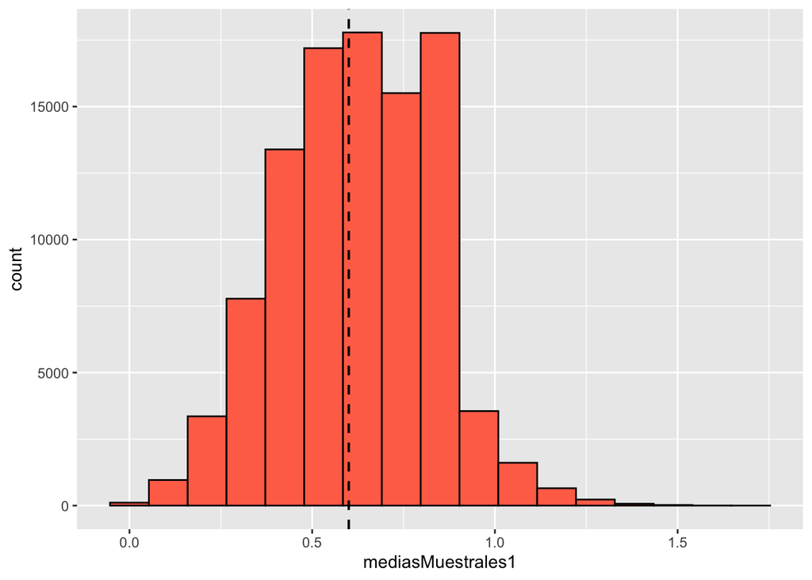

```r
ggplot() +
  geom_histogram(aes(x = mediasMuestrales1), bins = 17, fill="coral1", color="black") +
  geom_vline(xintercept = mean(mediasMuestrales1), col="black", linetype="dashed", size=0.7)
```

Y para medias muestrales para muestras de 30 repetimos el histograma.

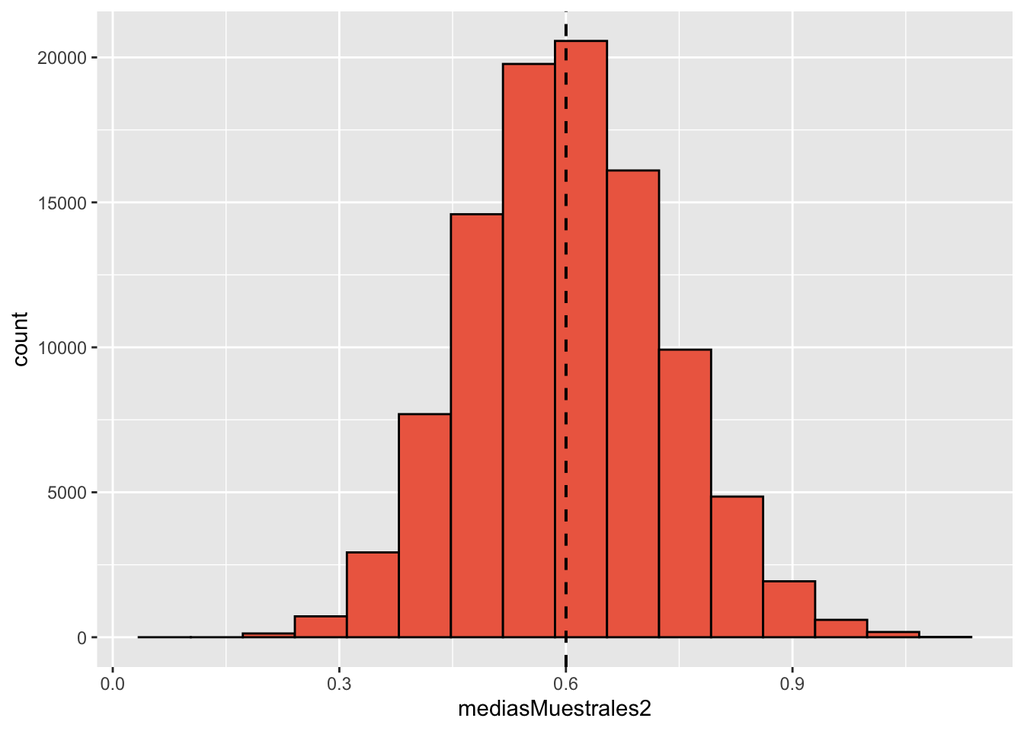

```r
ggplot() +
  geom_histogram(aes(x = mediasMuestrales2), bins = 16, fill="coral2", color="black") +
  geom_vline(xintercept = mean(mediasMuestrales1), col="black", linetype="dashed", size=0.7)
```

Otra gráfica que nos ayuda a ilustrar los datos es el *boxplot*.

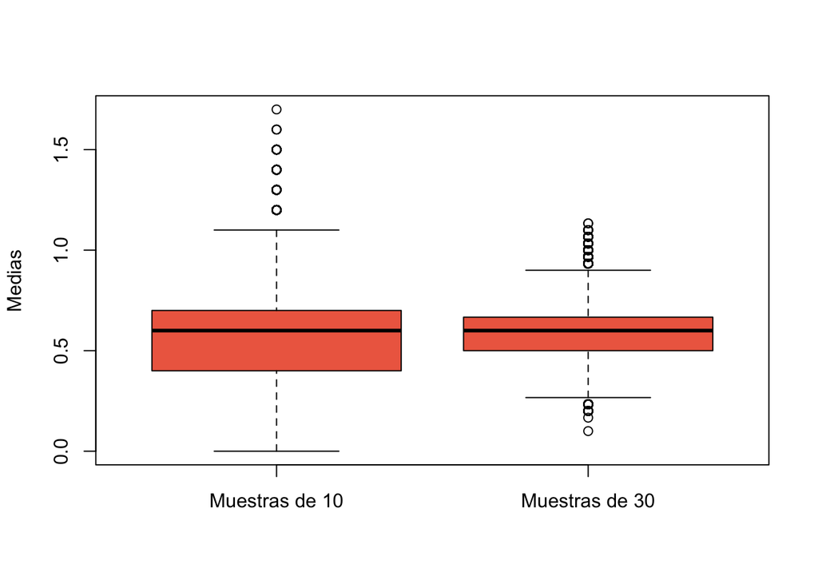

```r
bxp_cty = boxplot(na.omit(mediasMuestrales1), mediasMuestrales2, col="coral2",names = c("Muestras de 10","Muestras de 30"),ylab="Medias")
```

Por ejemplo podemos ver como cuando aumentamos el tamaño de las muestras (de 10 a 30) la varianza de la distribución de la media muestral disminuye. De hecho, sabemos que la desviación estándar de la distribución de la media muestral cumple que $s_1/s_2 \sim \sqrt{n_2/n_1} = \sqrt 3$, lo cual se cumple en nuestro caso con error menor de un 1%:

```r
(sqrt(3) - sd(mediasMuestrales1)/sd(mediasMuestrales2)) / sqrt(3)
```

```
## [1] -0.005002148
```

## Apartado 3

Suponiendo que X1 y X2, para saber los posibles valores de la suma usamos el mínimo valor de cada variable, 0, y el máximo de cada una, 2 y 3. Es decir que la suma puede ir de 0 a 5. Para obtener la tabla de probabilidades realizaremos el siguiente cálculo.

```r
valor1 = c(0,1,2,3)
valor2 = c(0,1,2)
prob1 = c(64/125, 48/125, 12/125, 1/125)
prob2 = c(1/2,1/4,1/4)
```

```r
posSum = outer(valor2,valor1, FUN = "+")
posSum
```

```
##      [,1] [,2] [,3] [,4]
## [1,]    0    1    2    3
## [2,]    1    2    3    4
## [3,]    2    3    4    5
```

```r
posProb = prob2 %*% t(prob1)
posProb
```

```
##       [,1]  [,2]  [,3]  [,4]
## [1,] 0.256 0.192 0.048 0.004
## [2,] 0.128 0.096 0.024 0.002
## [3,] 0.128 0.096 0.024 0.002
```

Pasamos estas matrices a un *dataframe* donde tengamos 2 columnas, una con las posibles sumas y otra con las probabilidades de obtener un resultado concreto en cada variable.

```r
data.frame(c(posProb),c(posSum)) -> data
```

Un vez que tenemos la tabla `data`, calculamos la tabla de probabilidades de la suma de X1 y X2, agrupando todas las posibles sumas, y sumando las probabilidades asociadas a cada suma.

```r
data %>% group_by(dado=c.posSum.) %>% summarize(prob=sum(c.posProb.))-> probabilidades
probabilidades
```

```
## # A tibble: 6 × 2
##    dado  prob
##   <dbl> <dbl>
## 1     0 0.256
## 2     1 0.32
## 3     2 0.272
## 4     3 0.124
## 5     4 0.026
## 6     5 0.002
```

## Apartado 4

Una vez que tenemos la tabla de probabilidades, calculamos la media de la suma de X1 y X1 de la forma habitual:

```r
weighted.mean(probabilidades$dado,probabilidades$prob )
```

```
## [1] 1.35
```

Para comprobar que hemos realizado bien el análisis, vamos a simular este caso. Generamos dos conjuntos X1 y X1 y los sumamos.

```r
k = 100000
X1 = sample(valor1, k, prob = prob1, replace = TRUE)
X2 = sample(valor2, k, prob = prob2, replace = TRUE)
suma = X1+X2
mean(suma)
```

```
## [1] 1.34472
```

Vemos que obtenemos la misma media que el cálculo teórico.

# Ejercicio 2

La tabla de datos no cumple los principios de tidy data que hemos visto en clase. Tu tarea en este ejercicio es explicar por qué no se cumplen y obtener una tabla de datos limpios con la misma información usando tidyR.

```r
library(readr)
```

Empezamos haciendo una pequeña visualización de los datos para hacernos una idea de la tabla:

```r
datos <- read_csv("data/testResults.csv")
head(datos)
```

```
## # A tibble: 6 × 9
##   name       id gender_age test_number week1 week2 week3 week4 week5
##   <chr>   <dbl> <chr>            <dbl> <dbl> <dbl> <dbl> <dbl> <dbl>
## 1 Jacob     108 m_20                 1     8     5     7     5     6
## 2 Jacob     108 m_20                 2     2     2     4     0     3
## 3 Michael   490 m_19                 1    10     0     5     4     0
## 4 Michael   490 m_19                 2     9    10     8    10     9
## 5 Matthew   424 m_18                 1     6     0     0     1    10
## 6 Matthew   424 m_18                 2     3     4     2     5     8
```

En primer lugar separamos la columna `gender_age` en dos columna, `gender` y `age`, y a continuación transformamos las columnas de `week` en dos columnas que dices que semana es y el valor asociado.

```r
datosLimpios <- datos %>%
  separate(gender_age, into = c("gender", "age"), sep = "_", convert = TRUE) %>%
  pivot_longer(c("week1", "week2", "week3", "week4", "week5"), names_to = "week_number",
               values_to = "value")
```

Después transformamos la columna de `week`y la de `gender` en factores.

```r
datosLimpios$gender=factor( datosLimpios$gender, levels = c("m","f"),labels = c("Male","Female") )
datosLimpios$week_number=factor(datosLimpios$week_number,levels = paste("week", 1:7, sep = ""),labels =
                                  paste("week", 1:7, sep = "") )
```

Mostramos el resultado

```r
head(datosLimpios)
```

```
## # A tibble: 6 × 7
##   name     id gender   age test_number week_number value
##   <chr> <dbl> <fct>  <int>       <dbl> <fct>       <dbl>
## 1 Jacob   108 Male      20           1 week1           8
## 2 Jacob   108 Male      20           1 week2           5
## 3 Jacob   108 Male      20           1 week3           7
## 4 Jacob   108 Male      20           1 week4           5
## 5 Jacob   108 Male      20           1 week5           6
## 6 Jacob   108 Male      20           2 week1           2
```